# Household Travel Survey: Commuting Data

Suzanne Childress & Mary Richards

March 30, 2021

This report presents preliminary findings for commuting trends based on the 2019 Household Travel Survey (HTS), a survey conducted every other year to determine travel patterns for individuals living within PSRC’s four-county jurisdiction.  
The main area of focus for this report:  
**How does the distance or commute time from home to your primary workplace vary by income and race?**

## Defining the Variables

### *Commuting Trips*

This analysis will focus on the commute trips of people who usually work outside the home.

Commute trips will be defined as those where one of the trip ends is a regular workplace - based on the survey logic, the origin or destination purpose is ‘Went to primary workplace’

Based on the total number of trips (72,855) documented as part of the 2019 survey results, 20% (14,501) were recorded as being commute trips. When trip weights are taken into consideration, **24% of the trips in the region are for commuting**.  
*Compared to national data:*  
This value reflects a slightly different finding compared to the 2017 National Household Travel Survey (NHTS). In [“Summary of Travel Trends”](https://nhts.ornl.gov/assets/2017_nhts_summary_travel_trends.pdf) Based on Table 5c (p. 18), approximately 17% of average annual person trips are to travel to or from work (546 out of 3,140). These trips include those taken on the weekends, defined by the [2009 NHTS documentation](https://nhts.ornl.gov/2009/pub/Weekday%20Travel%20FAQ.pdf) as “travel began at 6pm on Friday and ran through Saturday and all day Sunday.”  
For trips made on weekdays, 23% of trips are related to work (trip purpose = to/from work and work-related, based on 1990 NPTS design, *WHYTRP90*) or 15% (based on trip destination purpose, *WHYTO*, or trip purpose summary, *WHYTRP1S*). This disparity may be due to survey design - these latter variables include “home” as a destination purpose and these “home” trips are approximately 35% of all weekday trips.  
Based on Table 6c (p. 22), households annually make an average of 450 vehicle trips to/from work out of a total of 1,865 trips for all purposes, or 24%.

### *Commuters*

This subset of the respondents are based on the following survey questions:

- **“Primary type of employment?”**
- **“Please answer for your primary jobs where you work the most hours per week”**
  - “Usual work location?”

For this analysis, commuters are those with:

1. full-time or part-time paid employment or those who identified as self-employed with workplaces.
2. workplaces that are not at home
3. commute distances less than 200 miles

| Employment | Sample Size | 2019 Estimate | 2019 Percent |
| --- | --- | --- | --- |
| Employed full time (35+ hours/week, paid) | 2,319 | 1,354,787 | 85.17% |
| Employed part time (fewer than 35 hours/week, paid) | 288 | 196,916 | 12.38% |
| Self-employed | 97 | 39,074 | 2.46% |

| Workplace | Sample Size | 2019 Estimate | 2019 Percent |
| --- | --- | --- | --- |
| Drives for a living (e.g., bus driver, salesperson) | 48 | 57,289 | 3.60% |
| Usually the same location (outside home) | 2,313 | 1,284,117 | 80.72% |
| Workplace regularly varies (different offices or jobsites) | 343 | 249,371 | 15.68% |

Out of a total 5,711 people who responded to the 2019 travel survey, there were **2,704** individuals employed outside of the home who commute by automobile less than 200 miles (more information about the full range of employment/workplace responses is located at the end of the report in Background: Sample). The commute distance limit was intended to remove outliers.  
**These individuals represent approximately 39% of the people in the region.**

## General commute statistics

### Methodology

Commute travel times and distances were found using the [Google Distance Matrix API](https://developers.google.com/maps/documentation/distance-matrix/overview). Survey respondents reported home locations and work locations for all household workers. Google travel time and distance data were pulled from the API given these locations, assuming an 8am travel time in April of 2019.

### **Commute distance**

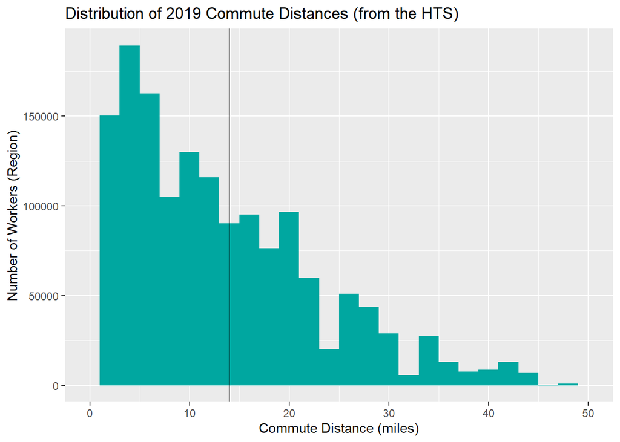

*The vertical line at x=**13.97 miles** represents the average distance traveled by workers*

*Share of workers in the region with auto commutes*

| Distance | 2019 Estimate | 2019 Percent | 2019 Average | Minimum | Maximum | Sample Size | Sample Percent |
| --- | --- | --- | --- | --- | --- | --- | --- |
| <3 miles (very short) | 209,061 | 13.14% | 1.62 | 0 | 3 | 817 | 30.21% |
| 3-10 miles (short) | 520,898 | 32.74% | 6.13 | 3 | 10 | 968 | 35.80% |
| 10-20 miles (average) | 482,898 | 30.36% | 14.48 | 10 | 20 | 618 | 22.86% |
| 20-50 miles (long) | 344,184 | 21.64% | 27.57 | 20 | 48 | 276 | 10.21% |
| 50+ miles (very long) | 33,737 | 2.12% | 65.69 | 52 | 103 | 25 | 0.92% |

#### 1. Income

Lower income workers tend to have shorter commutes. For example, workers with incomes between $10,000 and $24,999 have commutes that are about 7 miles, while workers with incomes between $75,000 and $99,999 have commutes that are about 15 miles. The average travel distance to work is highest for workers in the $150,000-$199,999 income bracket - about 18 miles - with those in higher income brackets having shorter commutes about 15 miles.

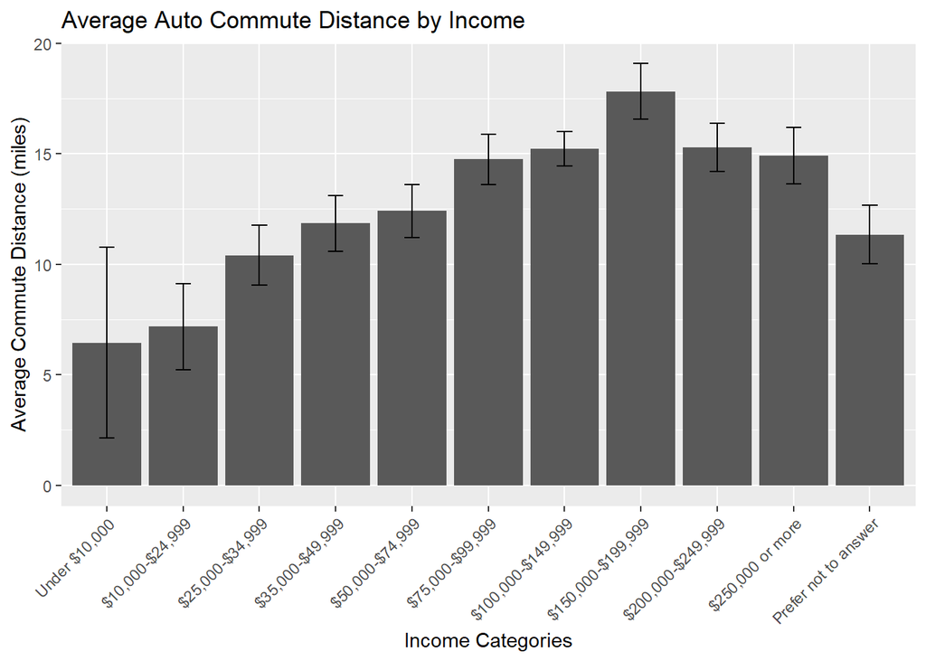

*The average commuting distance (miles) by income*

| Income | 2019 Estimate | 2019 Percent | 2019 Average | SD | SE | CI 90% | CI 95% | Sample Size |
| --- | --- | --- | --- | --- | --- | --- | --- | --- |
| Under $10,000 | 12,928 | 0.81% | 6.45 | 7.61 | 2.20 | 3.61 | 4.31 | 12 |
| $10,000-$24,999 | 56,470 | 3.55% | 7.18 | 8.34 | 1.00 | 1.64 | 1.95 | 70 |
| $25,000-$34,999 | 60,586 | 3.81% | 10.41 | 7.23 | 0.69 | 1.13 | 1.35 | 111 |
| $35,000-$49,999 | 113,998 | 7.17% | 11.85 | 9.05 | 0.64 | 1.06 | 1.26 | 199 |
| $50,000-$74,999 | 211,106 | 13.27% | 12.41 | 11.66 | 0.61 | 1.00 | 1.19 | 366 |
| $75,000-$99,999 | 190,867 | 12.00% | 14.75 | 11.24 | 0.58 | 0.95 | 1.14 | 375 |
| $100,000-$149,999 | 313,578 | 19.71% | 15.23 | 9.94 | 0.41 | 0.67 | 0.79 | 602 |
| $150,000-$199,999 | 254,263 | 15.98% | 17.82 | 11.37 | 0.64 | 1.05 | 1.26 | 315 |
| $200,000-$249,999 | 117,506 | 7.39% | 15.29 | 8.48 | 0.56 | 0.91 | 1.09 | 233 |
| $250,000 or more | 78,718 | 4.95% | 14.91 | 9.63 | 0.65 | 1.07 | 1.27 | 220 |
| Prefer not to answer | 180,756 | 11.36% | 11.34 | 9.62 | 0.68 | 1.12 | 1.33 | 201 |

#### 2. Race

People who identify as White Only have the farthest commutes (15 miles). The margins of error for African American and Hispanic groups are relatively large due to the small sample sizes.

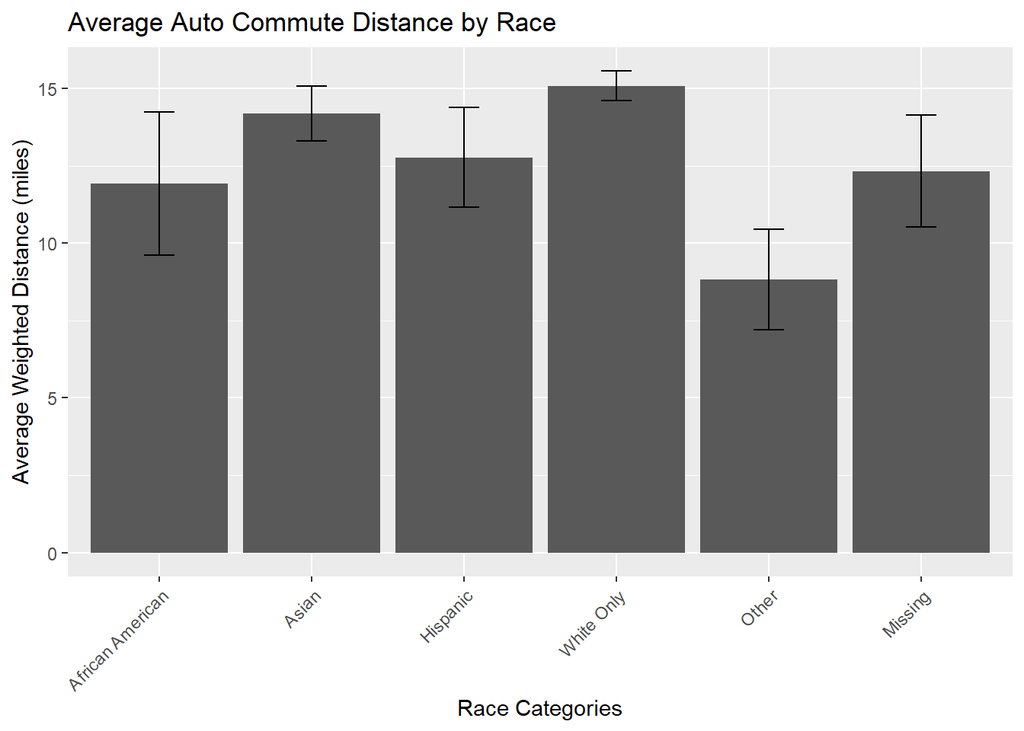

*The average commuting distance by race*

| Race | 2019 Estimate | 2019 Percent | 2019 Average | SD | SE | CI 90% | CI 95% | Sample Size |
| --- | --- | --- | --- | --- | --- | --- | --- | --- |
| African American | 59,789 | 3.76% | 11.92 | 9.61 | 1.18 | 1.95 | 2.32 | 66 |
| Asian | 170,852 | 10.74% | 14.19 | 8.86 | 0.45 | 0.75 | 0.89 | 382 |
| Hispanic | 86,397 | 5.43% | 12.77 | 9.05 | 0.82 | 1.35 | 1.61 | 122 |
| White Only | 957,188 | 60.17% | 15.08 | 10.57 | 0.24 | 0.40 | 0.48 | 1,873 |
| Other | 98,030 | 6.16% | 8.83 | 9.05 | 0.83 | 1.36 | 1.63 | 119 |
| Missing | 218,520 | 13.74% | 12.33 | 10.96 | 0.92 | 1.51 | 1.80 | 142 |

##### Aggregated Race

Because of small sample sizes, some of the respondents have been aggregated. For this analysis, respondents who identified as African American, Hispanic, and Other were aggregated.

**African American, Hispanic, and Other**

The margin of error for the Other POC group is distinct from respondents identifying as Asian or White Only.

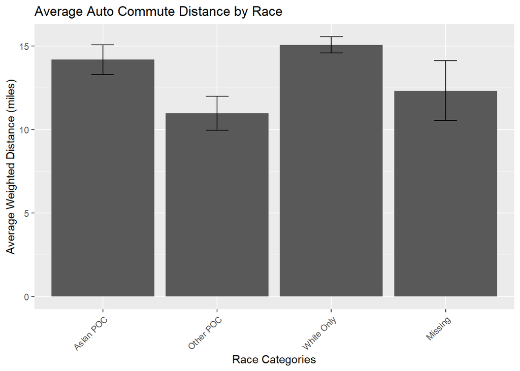

*The average commuting distance by race*

| Race | 2019 Estimate | 2019 Percent | 2019 Average | SD | SE | CI 90% | CI 95% | Sample Size |
| --- | --- | --- | --- | --- | --- | --- | --- | --- |
| Asian POC | 170,852 | 10.74% | 14.19 | 8.86 | 0.45 | 0.75 | 0.89 | 382 |
| Other POC | 244,217 | 15.35% | 10.98 | 9.15 | 0.52 | 0.86 | 1.02 | 307 |
| White Only | 957,188 | 60.17% | 15.08 | 10.57 | 0.24 | 0.40 | 0.48 | 1,873 |
| Missing | 218,520 | 13.74% | 12.33 | 10.96 | 0.92 | 1.51 | 1.80 | 142 |

#### 3. Gender

People who identify as male have the farthest commute (15 miles). Females have shorter commutes (13 miles), and people of another gender or who prefer not to answer do not have enough samples to draw a statistical conclusion.

Because of the small sample sizes for respondents identifying as Another or choosing not to answer, these respondents were removed from the graph:

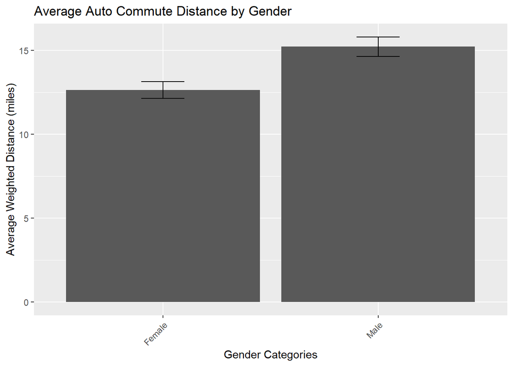

*The average commuting distance by gender*

| Gender | 2019 Estimate | 2019 Percent | 2019 Average | SD | SE | CI 90% | CI 95% | Sample Size |
| --- | --- | --- | --- | --- | --- | --- | --- | --- |
| Another | 4,570 | 0.29% | 8.45 | 4.28 | 1.11 | 1.82 | 2.17 | 15 |
| Female | 742,163 | 46.65% | 12.64 | 9.25 | 0.26 | 0.42 | 0.50 | 1,297 |
| Male | 825,469 | 51.89% | 15.23 | 11.04 | 0.30 | 0.49 | 0.59 | 1,364 |
| Prefer not to answer | 18,576 | 1.17% | 13.06 | 12.17 | 2.30 | 3.78 | 4.51 | 28 |

### **Commute duration**

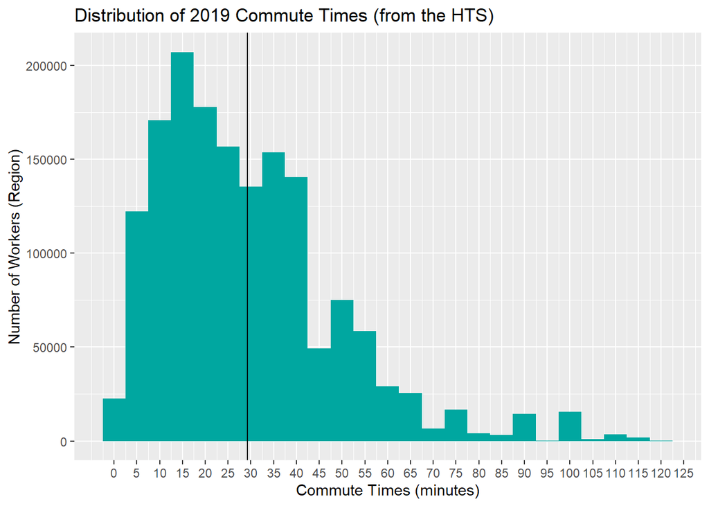

*The vertical line at x=**29.30 minutes** represents the average commute duration for workers*

*Share of workers with auto commutes*

| Time | 2019 Estimate | 2019 Percent | 2019 Average | Minimum | Maximum | Sample Size | Sample Percent |
| --- | --- | --- | --- | --- | --- | --- | --- |
| <10 minutes | 235,435 | 14.80% | 6.46 | 0 | 10 | 634 | 23.45% |
| 10-20 minutes | 391,939 | 24.64% | 15.35 | 10 | 20 | 755 | 27.92% |
| 20-30 minutes | 300,661 | 18.90% | 25.15 | 20 | 30 | 577 | 21.34% |
| 30-45 minutes | 372,108 | 23.39% | 36.68 | 30 | 45 | 503 | 18.60% |
| 45-60 minutes | 177,814 | 11.18% | 51.05 | 45 | 60 | 138 | 5.10% |
| 60+ minutes | 112,820 | 7.09% | 77.89 | 60 | 119 | 97 | 3.59% |

#### 1. Income

The time spent commuting to work increases with income until $75,000, when it stays relatively consistent at aroudn 33 minutes. The average commuting time to work for people in households with incomes between $10,000 and $24,999 is 20 minutes. The average time to work for people in households with incomes between $75,000-$99,999 is approximately 65% longer.

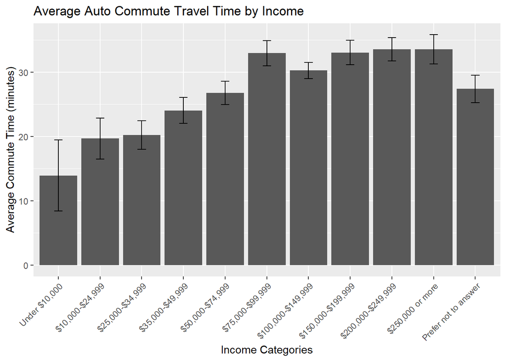

*The average commuting duration by income*

| Income | 2019 Estimate | 2019 Percent | 2019 Average | SD | SE | CI 90% | CI 95% | Sample Size |
| --- | --- | --- | --- | --- | --- | --- | --- | --- |
| Under $10,000 | 12,928 | 0.81% | 13.91 | 9.80 | 2.83 | 4.65 | 5.54 | 12 |
| $10,000-$24,999 | 56,470 | 3.55% | 19.66 | 13.58 | 1.62 | 2.67 | 3.18 | 70 |
| $25,000-$34,999 | 60,586 | 3.81% | 20.20 | 11.98 | 1.14 | 1.87 | 2.23 | 111 |
| $35,000-$49,999 | 113,998 | 7.17% | 24.03 | 14.55 | 1.03 | 1.70 | 2.02 | 199 |
| $50,000-$74,999 | 211,106 | 13.27% | 26.77 | 17.46 | 0.91 | 1.50 | 1.79 | 366 |
| $75,000-$99,999 | 190,867 | 12.00% | 32.95 | 19.38 | 1.00 | 1.65 | 1.96 | 375 |
| $100,000-$149,999 | 313,578 | 19.71% | 30.25 | 15.93 | 0.65 | 1.07 | 1.27 | 602 |
| $150,000-$199,999 | 254,263 | 15.98% | 33.05 | 16.99 | 0.96 | 1.57 | 1.88 | 315 |
| $200,000-$249,999 | 117,506 | 7.39% | 33.53 | 14.18 | 0.93 | 1.53 | 1.82 | 233 |
| $250,000 or more | 78,718 | 4.95% | 33.53 | 17.27 | 1.16 | 1.92 | 2.28 | 220 |
| Prefer not to answer | 180,756 | 11.36% | 27.38 | 15.35 | 1.08 | 1.78 | 2.12 | 201 |

#### 2. Race

African American, Asian, Hispanic, and White Only workers all have commutes around 30 minutes long. Although African Americans appear to have slightly shorter commutes, the margin of error is larger because of the small sample size. People who identify as Other have the shortest commutes at about 18 minutes.

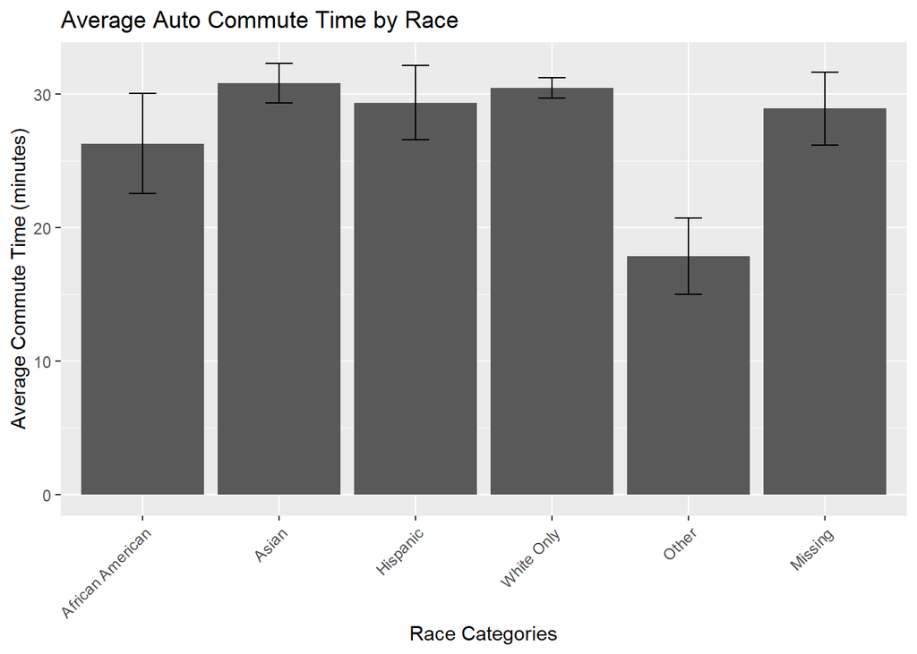

*The average commuting duration by race*

| Race | 2019 Estimate | 2019 Percent | 2019 Average | SD | SE | CI 90% | CI 95% | Sample Size |
| --- | --- | --- | --- | --- | --- | --- | --- | --- |
| African American | 59,789 | 3.76% | 26.30 | 15.53 | 1.91 | 3.14 | 3.75 | 66 |
| Asian | 170,852 | 10.74% | 30.83 | 14.51 | 0.74 | 1.22 | 1.46 | 382 |
| Hispanic | 86,397 | 5.43% | 29.37 | 15.61 | 1.41 | 2.32 | 2.77 | 122 |
| White Only | 957,188 | 60.17% | 30.47 | 16.98 | 0.39 | 0.65 | 0.77 | 1,873 |
| Other | 98,030 | 6.16% | 17.85 | 15.97 | 1.46 | 2.41 | 2.87 | 119 |
| Missing | 218,520 | 13.74% | 28.92 | 16.66 | 1.40 | 2.30 | 2.74 | 142 |

##### Aggregated Race

Because of small sample sizes, some of the respondents have been aggregated. For this analysis, respondents who identified as African American, Hispanic, and Other were aggregated.

**African American, Hispanic, and Other**  
People who are categorized as Other POC (African American, Hispanic, or Other) have shorter commutes (24 minutes), while Asian POC and White Only individuals have longer commutes (around 30 minutes).

The margin of error for the Other POC group is distinct from respondents identifying as Asian or White Only.

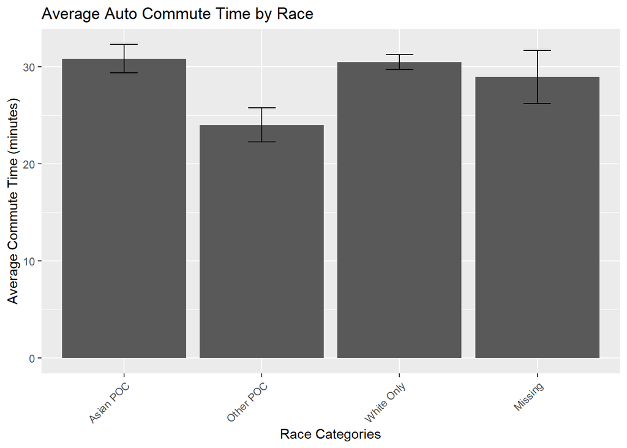

| Race | 2019 Estimate | 2019 Percent | 2019 Average | SD | SE | CI 90% | CI 95% | Sample Size |
| --- | --- | --- | --- | --- | --- | --- | --- | --- |
| Asian POC | 170,852 | 10.74% | 30.83 | 14.51 | 0.74 | 1.22 | 1.46 | 382 |
| Other POC | 244,217 | 15.35% | 23.99 | 15.69 | 0.90 | 1.47 | 1.76 | 307 |
| White Only | 957,188 | 60.17% | 30.47 | 16.98 | 0.39 | 0.65 | 0.77 | 1,873 |
| Missing | 218,520 | 13.74% | 28.92 | 16.66 | 1.40 | 2.30 | 2.74 | 142 |

#### 3. Gender

People who identify as male have the longest commutes (31 minutes). Females have shorter commutes (27 minutes), and people of another gender or who prefer not answer do not have enough samples to draw a statistical conclusion.

Because of the small sample sizes for respondents identifying as Another or choosing not to answer, these respondents were removed from the graph:

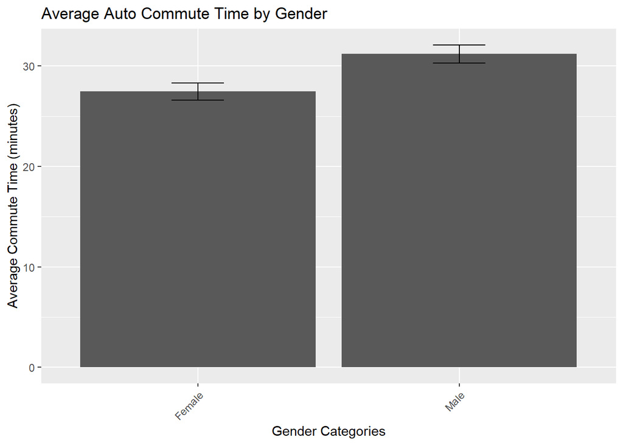

| Gender | 2019 Estimate | 2019 Percent | 2019 Average | SD | SE | CI 90% | CI 95% | Sample Size |
| --- | --- | --- | --- | --- | --- | --- | --- | --- |
| Another | 4,570 | 0.29% | 17.74 | 8.70 | 2.25 | 3.70 | 4.40 | 15 |
| Female | 742,163 | 46.65% | 27.46 | 15.80 | 0.44 | 0.72 | 0.86 | 1,297 |
| Male | 825,469 | 51.89% | 31.20 | 17.20 | 0.47 | 0.77 | 0.91 | 1,364 |
| Prefer not to answer | 18,576 | 1.17% | 21.21 | 15.88 | 3.00 | 4.94 | 5.88 | 28 |

### Summary: Commute Trends

[output not shown]

## Travel Time Trends

Travel time to work has increased in the region since 1980 from about 23 minutes to 32 minutes in 2018. Those living in King County have consistently experienced shorter (or equal) commute times compared to the region. Pierce County residents have experienced the largest increase over time (a change of over 10 minutes).

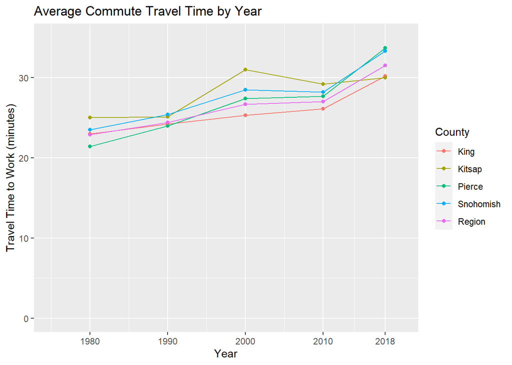

**Average commute time (minutes) by county and region over time.**  
The data is from the American Community Survey (ACS).

| Counties | 1980 | 1990 | 2000 | 2010 | 2018 |
| --- | --- | --- | --- | --- | --- |
| King | 23 | 24.2 | 25.3 | 26.1 | 30.2 |
| Kitsap | 25 | 25.1 | 31 | 29.2 | 30 |
| Pierce | 21.4 | 24 | 27.4 | 27.7 | 33.7 |
| Snohomish | 23.5 | 25.4 | 28.5 | 28.2 | 33.3 |
| Region | 22.9 | 24.4 | 26.7 | 27 | 31.5 |

## Background: Sample

5,711 people responded to the 2019 survey and provided their employment status and workplace. These tables include all the possible survey responses for employment status and workplace.

### Employment Status

The following table shows the distribution of respondents’ employment status.

| Employment | Sample Size | 2019 Estimate | 2019 Percent |
| --- | --- | --- | --- |
| Employed full time (35+ hours/week, paid) | 2,811 | 1,687,954 | 41.66% |
| Employed part time (fewer than 35 hours/week, paid) | 428 | 274,028 | 6.76% |
| Self-employed | 346 | 166,300 | 4.10% |
| Unpaid volunteer or intern | 32 | 13,127 | 0.32% |
| Homemaker | 170 | 183,598 | 4.53% |
| Retired | 810 | 571,258 | 14.10% |
| Not currently employed | 313 | 235,731 | 5.82% |

### Workplace

The following table shows where workers go for work.

| Workplace | Sample Size | 2019 Estimate | 2019 Percent |
| --- | --- | --- | --- |
| At home (telecommute or self-employed with home office) | 271 | 136,682 | 3.37% |
| Drives for a living (e.g., bus driver, salesperson) | 78 | 75,233 | 1.86% |
| Usually the same location (outside home) | 2,668 | 1,505,449 | 37.16% |
| Workplace regularly varies (different offices or jobsites) | 568 | 410,918 | 10.14% |

Back to top